# Exploring Sentencing Data Notebook

## Fitting Lines to Data

Let’s make two example points, one at (1,2) and one at (3,5). In R, we will save this into a data frame using a vector of the x values, 1 and 3, and a vector of the matching y values, 2 and 5.

```r
twopoints <- data.frame(xvals = c(1,3), yvals = c(2,5), group=as.factor(1))
head(twopoints)
```

|  | xvals | yvals | group |
| --- | --- | --- | --- |
| 1 | 1 | 2 | 1 |
| 2 | 3 | 5 | 1 |

We can make a fairly boring plot of these two points.

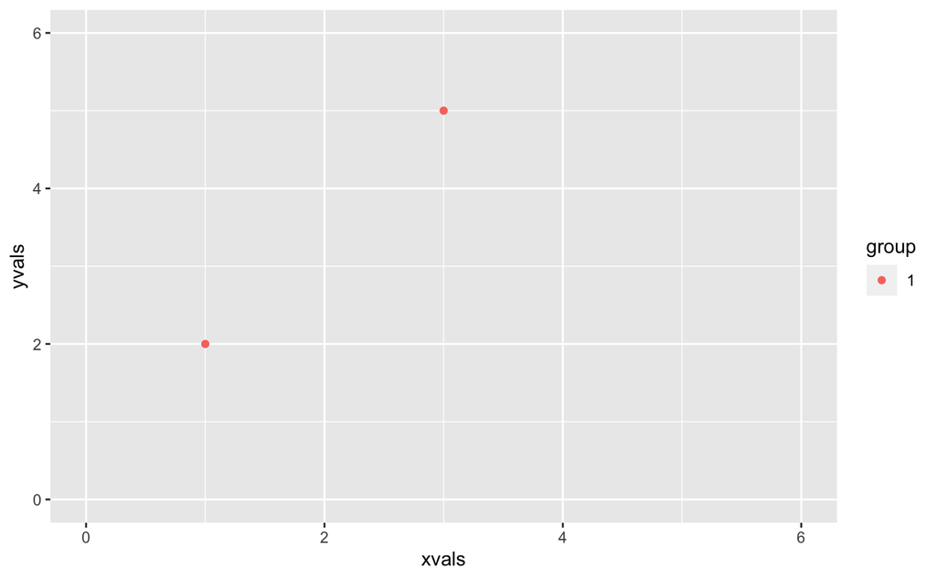

```r
twoplot <- ggplot(twopoints, aes(x=xvals, y=yvals, color=group)) +
  geom_point() +
  xlim(0,6) +
  ylim(0,6)
twoplot
```

In order to create a linear regression on these two points, we can think back to algebra and use the formula for a line.

$$y = m x + b$$

Fitting our line to the data is easy, we can solve in a number of ways. We can plug both these points into the equation and then solve the system together.

$$2 = m + b$$
$$5 = 3m+b$$
Here we have a system that has two equations and two unknowns, $m$ and $b$. We know this has a unique solution! We can solve this system using a variety of techniques. Try this using a technique you are comfortable with and verify that the solution passes through each of the two points.

$$y = \frac{3}{2} x+ \frac{1}{2}$$

We can plot the results. Here we use the `abline()` function which can be done inslope-intercept form.

```r
twoplot + geom_abline(slope=3/2, intercept = 1/2)
```

[output not shown]

```r
twolinear <- lm(formula = yvals ~ xvals, data=twopoints)
twolinear
```

[output not shown]

```r
twopoints$group = as.factor(1)
threepoints = rbind(twopoints, data.frame(xvals = 2, yvals = 3, group=as.factor(2)))
threepoints$yfit1 = threepoints$xvals*3/2+1/2
threepoints$yfit2 = threepoints$xvals+1
threepoints$yfit3 = threepoints$xvals*2-1

threeplot = ggplot(threepoints, aes(x=xvals, y = yvals, color=group)) + geom_point()  + xlim(0,6) + ylim(0,6)

grid.arrange(
threeplot + geom_abline(slope=3/2, intercept = 1/2)+  geom_segment(aes(xend = xvals, yend = yfit1)),
threeplot + geom_abline(slope=1, intercept = 1) + geom_segment(aes(xend = xvals, yend = yfit2)),
threeplot + geom_abline(slope=2, intercept = -1) +  geom_segment(aes(xend = xvals, yend = yfit3)),
ncol=3
)
```

[output not shown]

```r
threelinear = lm(formula=yvals~xvals, data=threepoints)
threelinear
```

[output not shown]

```r
threepoints$linfit = 1.5*threepoints$xvals + 0.3333
ggplot(threepoints, aes(x=xvals, y = yvals, color=group)) +
  geom_point()  +
  xlim(0,6) + ylim(0,6)+
  geom_abline(slope=1.5, intercept=0.3333) +
  geom_segment(aes(xend = xvals, yend = linfit))
```

[output not shown]

```r
pengscat = ggplot(penguins, aes(x=body_mass_g, y=flipper_length_mm)) + geom_point()
pengscat
```

[output not shown]

```r
pengfit = lm(formula = flipper_length_mm ~ body_mass_g, data = peng)
pengfit
```

[output not shown]

```r
pengscat + geom_abline(slope= 0.0152, intercept = 137.0396)
```

[output not shown]

## Categorical Data to Numerical Representations

```r
peng$isAdelie = ifelse(peng$species=='Adelie',1,0)
adelieplot = ggplot(peng, aes(x=isAdelie, y=flipper_length_mm)) + geom_point()
adelieplot
```

[output not shown]

```r
amodel = lm(formula = flipper_length_mm~isAdelie, data=peng)
amodel
```

[output not shown]

```r
adelieplot + geom_abline(slope=-19.35, intercept=209.45)
```

[output not shown]

```r
peng$isChinstrap = ifelse(peng$species=='Chinstrap',1,0)
peng$isGentoo = ifelse(peng$species=='Gentoo',1,0)

cmodel = lm(formula = flipper_length_mm~isChinstrap, data=peng)
gmodel = lm(formula = flipper_length_mm~isGentoo, data=peng)

speciesbase = ggplot(peng, aes(y=flipper_length_mm))
aplot= speciesbase + geom_point(aes(x=isAdelie)) + geom_abline(slope=amodel$coefficients[2], intercept=amodel$coefficients[1])
cplot = speciesbase + geom_point(aes(x=isChinstrap)) + geom_abline(slope=cmodel$coefficients[2], intercept=cmodel$coefficients[1])
gplot = speciesbase + geom_point(aes(x=isGentoo)) + geom_abline(slope=gmodel$coefficients[2], intercept=gmodel$coefficients[1])

grid.arrange( aplot, cplot, gplot, ncol=3)
```

[output not shown]

```r
linmodel <- lm(flipper_length_mm ~ species, data = peng)
linmodel
```

[output not shown]

```r
peng_encoded = peng %>% mutate(value = 1) %>% spread(species, value, fill = 0 )
head(peng_encoded)
```

[output not shown]